# RClub_Assignment03

## 4.Take the first faceted plot in this section:

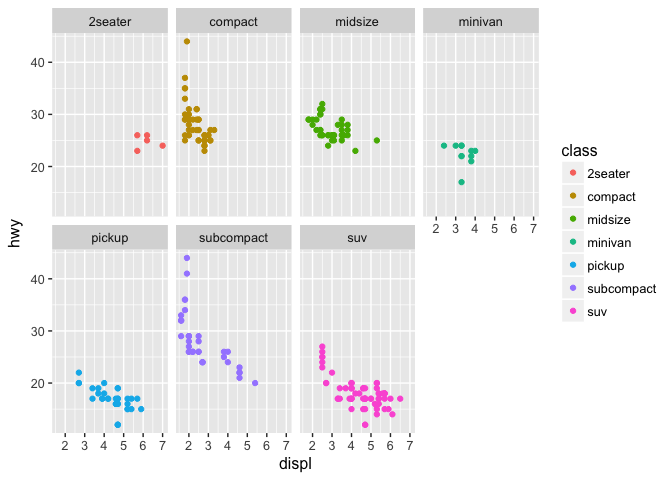

```r
ggplot(data = mpg) +
  geom_point(mapping = aes(x = displ, y = hwy, color=class)) +
  facet_wrap(~ class, nrow = 2)
```

```r
#it gives us more information for a specified model
```

### What are the advantages to using faceting instead of the colour aesthetic?

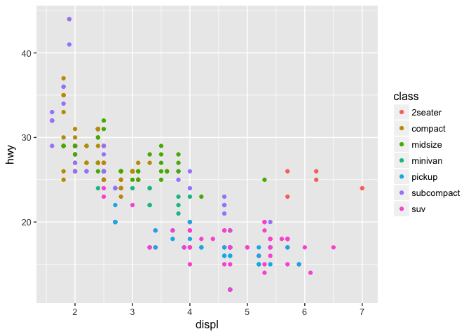

```r
ggplot(data = mpg) +
  geom_point(mapping = aes(x = displ, y = hwy, color = class))
```

### What are the disadvantages?

#### There is less data in each figure, we can’t see a strong negative relationship between displ and hwy as it was displayed in the color aesthetic figure.

### How might the balance change if you had a larger dataset?

#### Each figure may have a strong negative relationships between displ and hwy.

## 5.Read ?facet_wrap. What does nrow do? What does ncol do?

```r
?facet_wrap

#nrow and ncol represented the number of rows and columns will be created when you facet_warp your original plot.
```

### What other options control the layout of the individual panels?

##### Try scales, which can allow scales to vary across the panels

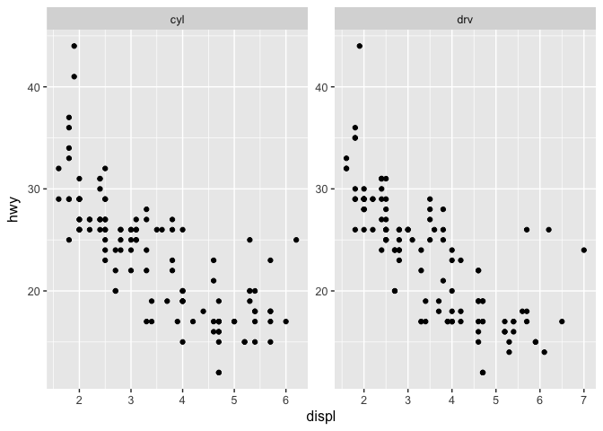

```r
ggplot(mpg, aes(displ, hwy)) +
  geom_point() +
  facet_wrap(~c("cyl", "drv"), scales = "free")
```

#### Try labeller, which control how labels are printed in panels

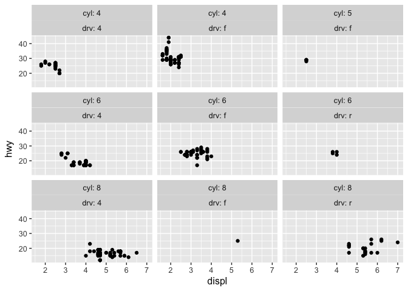

```r
ggplot(mpg, aes(displ, hwy)) +
  geom_point() +
  facet_wrap(c("cyl", "drv"), labeller = "label_both")
```

#### Try as.table, if can change the position of the panel according to the values. If TRUE, the default, the facets are laid out like a table with highest values at the bottom-right. If FALSE, the facets are laid out like a plot with the highest value at the top-right.

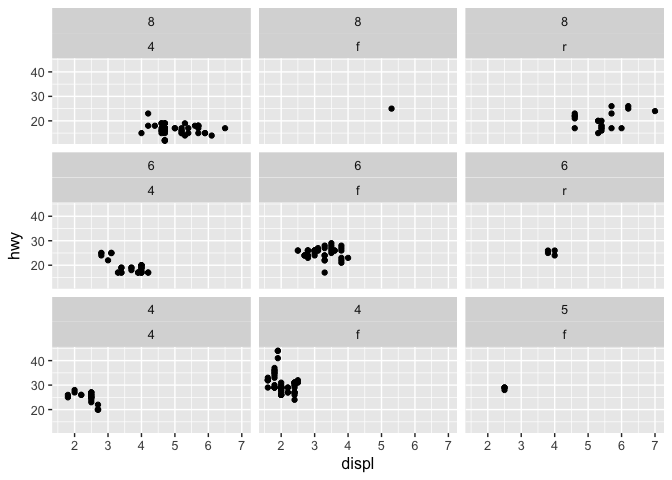

```r
ggplot(mpg, aes(displ, hwy)) +
  geom_point() +
  facet_wrap(c("cyl", "drv"), as.table = FALSE)
```

#### Try switch. Change the position of the labels. If “x”, the top labels will be displayed to the bottom. If “y”, the right-hand side labels will be displayed to the left. Can also be set to “both”.

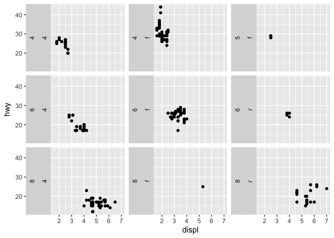

```r
ggplot(mpg, aes(displ, hwy)) +
  geom_point() +
  facet_wrap(c("cyl", "drv"), switch = "y")
```

#### Try drop ?

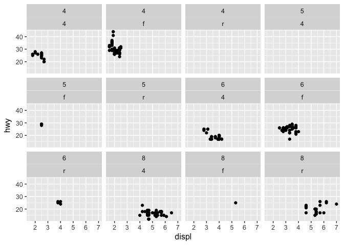

```r
ggplot(mpg, aes(displ, hwy)) +
  geom_point() +
  facet_wrap(c("cyl", "drv"), drop = FALSE)
```

#### Try strip.position, can place the labels on either of the four sides

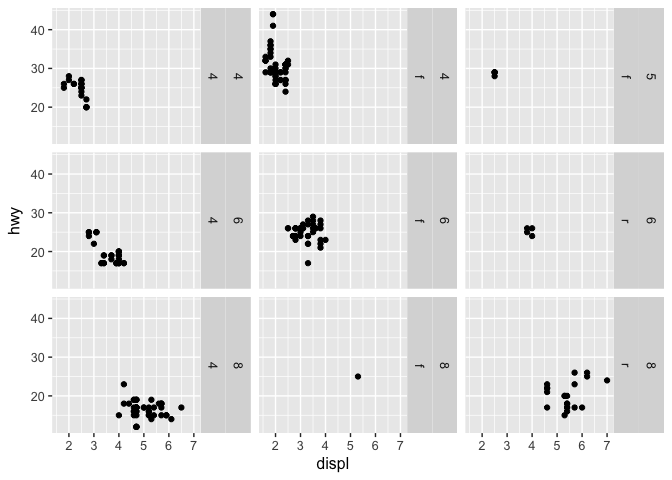

```r
ggplot(mpg, aes(displ, hwy)) +
  geom_point() +
  facet_wrap(c("cyl", "drv"), strip.position ="right")
```

#### Try shrink

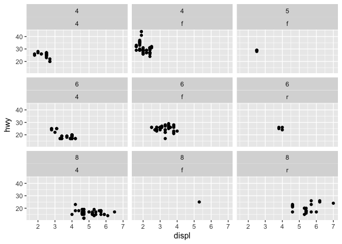

```r
par(mfrow=c(1,2))
ggplot(mpg, aes(displ, hwy)) +
  geom_point() +
  facet_wrap(c("cyl", "drv"), shrink =TRUE)
```

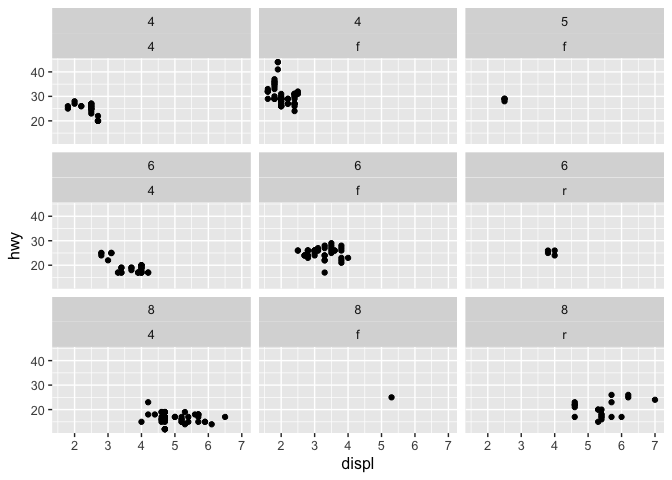

```r
ggplot(mpg, aes(displ, hwy)) +
  geom_point() +
  facet_wrap(c("cyl", "drv"), shrink =FALSE)
```

```r
##There's no difference???
```

### Why doesn’t facet_grid() have nrow and ncol variables?

```r
?facet_grid

##it was faceted according to the levels of variables. The number of rows or columns were determined by the levels of the variable.
```